# creatitng datafrome of application data

# BIVARIATE ANALYSIS

```python
numeric_data = final_df_no_outliers.select_dtypes(include=["number"])
```

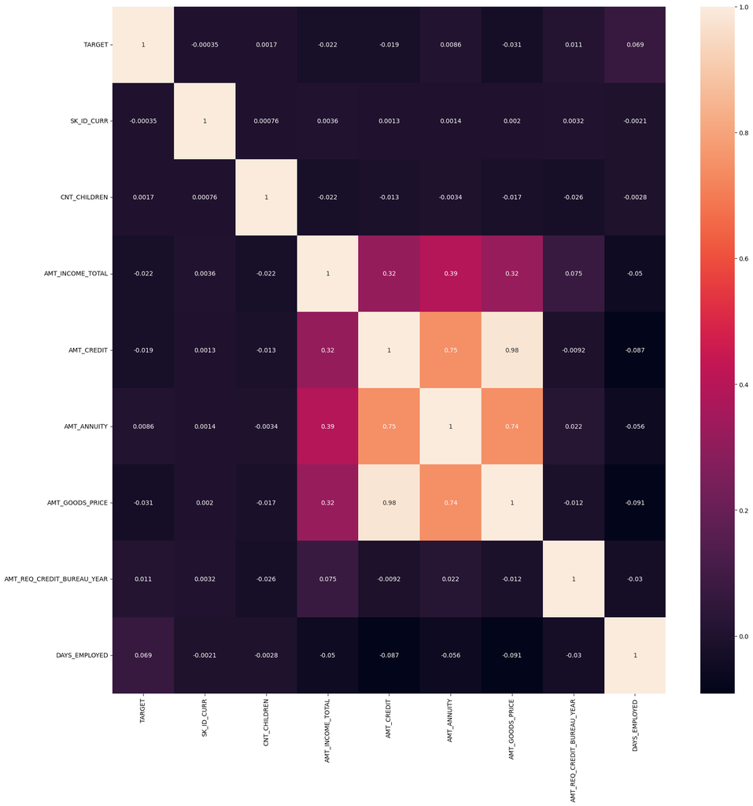

```python
plt.figure(figsize=(20, 20))
sns.heatmap(numeric_data.corr(),annot=True)
```

# Strong correlation between AMT_CREDIT and AMT_ANNUITY (0.75):This suggests that when the credit amount increases, the annuity amount also increases, which is logical because higher credit amounts typically require higher repayments.

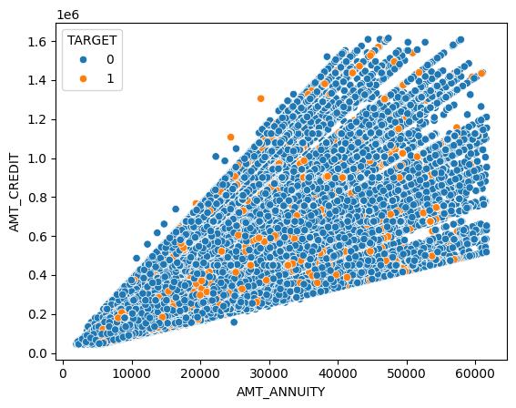

```python
sns.scatterplot(data=numeric_data, hue=numeric_data["TARGET"],y=numeric_data["AMT_CREDIT"],x=numeric_data["AMT_ANNUITY"])
```

# Strong correlation between AMT_ANNUITY and AMT_GOODS_PRICE (0.74): This suggests that the amount of goods purchased (e.g., loan for purchasing goods) is highly related to the annuity amount.

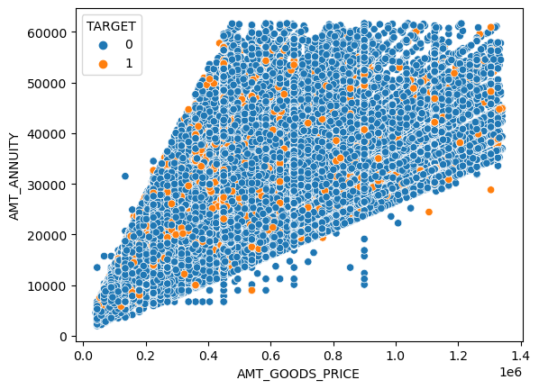

```python
sns.scatterplot(data=numeric_data, hue=numeric_data["TARGET"],y=numeric_data["AMT_ANNUITY"],x=numeric_data["AMT_GOODS_PRICE"])
```